# Abstract

### Part 2

In this part the SI-RWS is extended to become a SIR-RWS. It means that effect of **Recovery** from the disease is added to the model. The mechanism of recovery is introduced by making a small chance for each infected person to recover, each time step.

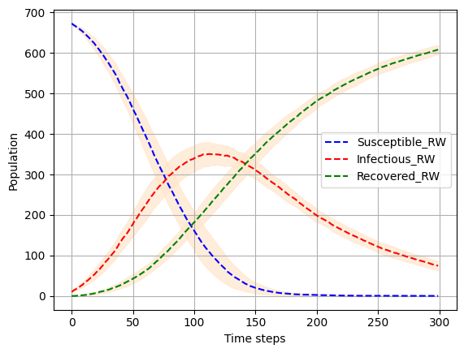

```python
RandomlyViral(Recovery = 'on').plot_simulation()
```

The main comment to this plot is recognising how easy it was to add this mechanism. The framework of making Monte Carlo checks for transferring walkers from one "State" to another seems very robust.

### Part 3

One term is added which is $\tau_{sick}$, which refers to the average time a person is infected before recovering.

$$ \begin{equation} \frac{dI(t)}{dt}=\beta(t).\frac{S(t)I(t)}{N}-\frac{1}{\tau_{sick}}.I(t) \tag{5} \end{equation} $$$$ \begin{equation} \frac{dR(t)}{dt}=\frac{1}{\tau_{sick}}.I(t) \tag{6} \end{equation} $$

Result of implementation is shown in Part 4 after finding values for $\beta$, and $\tau_{sick}$.

### Part 4

Like in Exercise 2 - Part 1, in this exercise we calculate $\beta$ and one more parameter which is $\tau_{sick}$. Then, we used these values in ODE-model.

```python
RandomlyViral(Recovery = 'on',time_steps=110).print_beta()
```

```
0.0626927436734449
```

To calculate $\tau_{sick}$ we combine equation (6) with a first order approximation of the derivative to yield:

$$ \begin{equation} \frac{\tau_{sick}}{dt} = -\frac{I_n}{(R_n - R_{n-1})} \tag{7} \end{equation} $$

While calculating $\tau_{sick}$ we ran into a different divide-by-zero-error. Due to the low recovery rate, each time step does not guarantee that the number of recoveries is greater than zero. To circumnavigate this issue we calculate the invers of each single value before calculating the mean and inverting back.

```python
RandomlyViral(Recovery = 'on').print_tau()
```

```
97.70749994473935
```

The value for $\tau_{sick}$ makes sense seeing that our chance of recovery per time step is 1%. Based on this we can imagine that it will take around 100 days to recover.

Plotting comparisons of ODE and RW results for SIR-model:

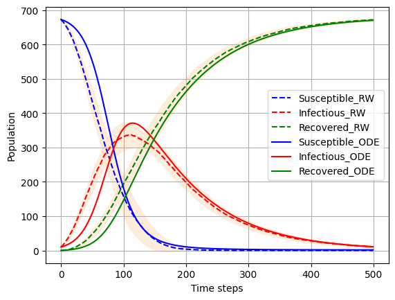

```python
RandomlyViral(model = 'ODE_SIR', Recovery = 'on', beta = 0.0627, tau = 97.7, time_steps = 500).plot_simulation()
```

Observations:

- Considering how differnt the two sets of curves are generated, it is quite intriguing how well they match with only calibrating two constants.

## Exercise 3: Implement your own scenario

In this task we could implement anything, but finally decided to add infection waves, removing the border around the grid & finally tried to fit it to some real world data. Quite notably, this fitting to real world data, will only be using infections of susceptible people, and recovery of infected people.

The data used was found at https://github.com/owid/covid-19-data (4)

First, the simplest change is made, which is just to remove the border around the grid which limits any movement that would go outside the grid to be a skipped movement instead.

The changed version, will let it move directly over the the opposite side.

Example:

pos1 = [$x$,$y$] = [$0$, $0$]

step = [$-1$,$0$]

previously:

pos2 = [$0-1=0$, $0+0=0$]

with borderless mode:

pos2 = [$0-1=x_{\text{max}}$, $0+0=0$]

Below is the code used earlier, which show the step and corrections to steps outside of the grid.

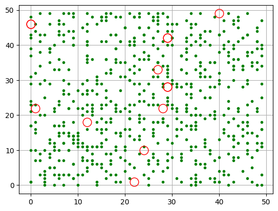

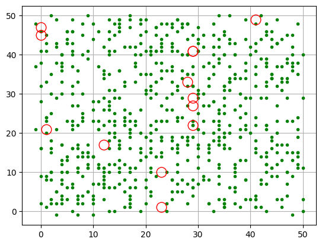

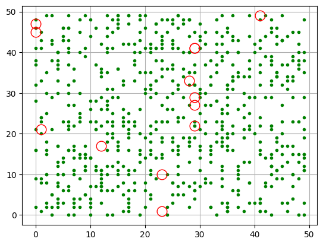

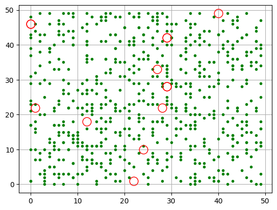

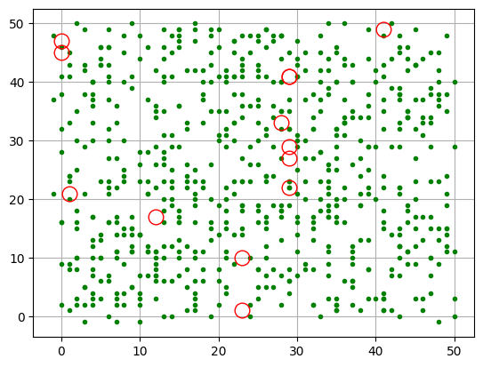

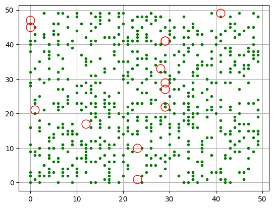

```python
seed = 9  # specifically chosen since a step outside the grid happens
RandomlyViral(Recovery='on',
              random_seed=seed).single_simulation()
RandomlyViral(Recovery='on',
              random_seed=seed, no_border=True).single_simulation()
```

The point of interest here, is the point moving outside the grid at [$x$, $y$] $\approx$ [$0$, $46$]

Now a actual simulation that uses this change compared to one without, below:

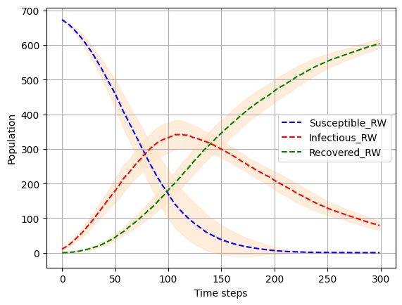

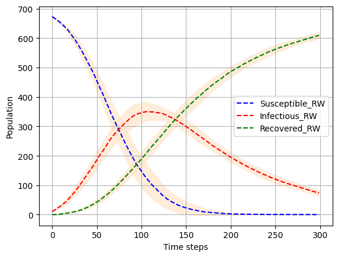

```python
iterations = 25  # less computing power
RandomlyViral(
    iterations=iterations,
    Recovery='on',
    random_seed=seed).plot_simulation()
RandomlyViral(
    iterations=iterations,
    Recovery='on',
    no_border=True,
    random_seed=seed).plot_simulation()
```

The result is basically a negligable difference. Then to confirm it is always the case, a bigger and smaller grid is used in the same way as above.

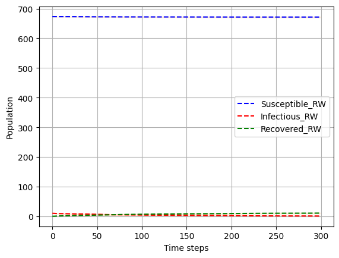

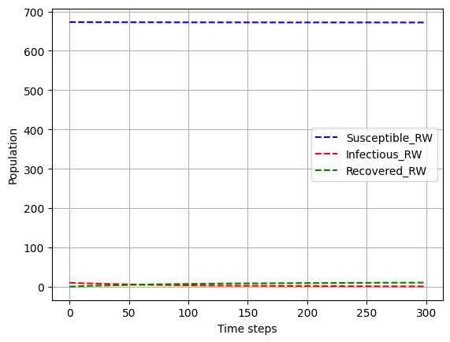

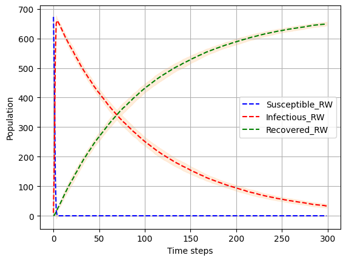

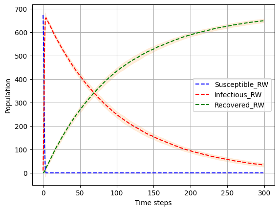

```python
# The following is a $10$ times bigger grid:
time_steps = 300
RandomlyViral(
    iterations=iterations,
    nx=500,
    ny=500,
    Recovery='on',
    random_seed=seed).plot_simulation()
RandomlyViral(
    iterations=iterations,
    nx=500,
    ny=500, Recovery='on',
    no_border=True,
    random_seed=seed).plot_simulation()

# The following is a $10$ times smaller grid:
RandomlyViral(
    iterations=iterations,
    nx=5,
    ny=5,
    Recovery='on',
    random_seed=seed).plot_simulation()
RandomlyViral(
    iterations=iterations,
    nx=5,
    ny=5, Recovery='on',
    no_border=True,
    random_seed=seed).plot_simulation()
```

The result is basically a negligable difference, again. Even though this result is incredibly boring, it basically means that the two reactions we expected are practically equally effective in their own right.

To explore this just a bit more, a change in number of movements is also tested. This is because this gives more time for the expected clumping behaviour to happen in the border case.

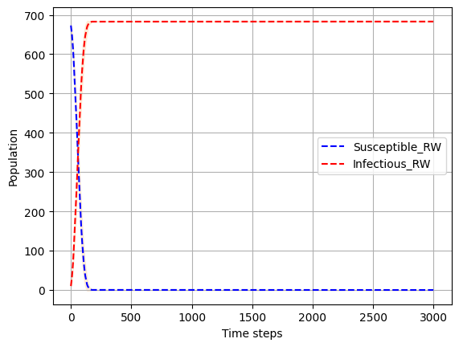

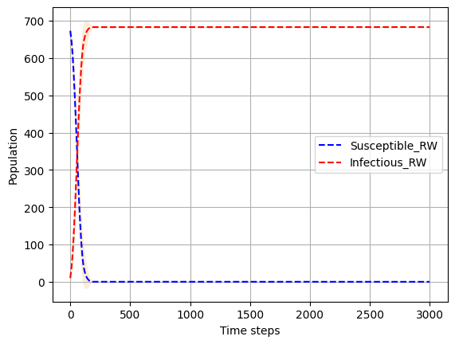

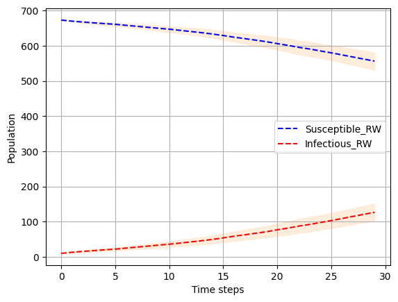

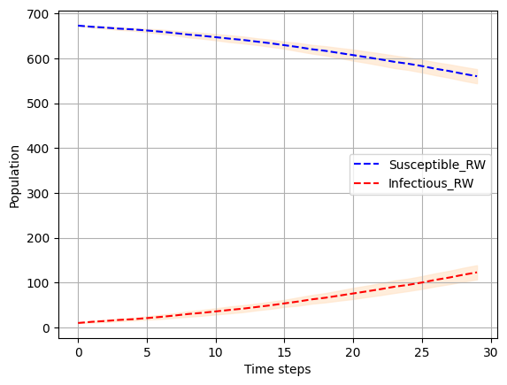

```python
# The following is a $10$ times number of time steps:
time_steps = 3000
RandomlyViral(
    time_steps=time_steps,
    random_seed=seed).plot_simulation()
RandomlyViral(
    time_steps=time_steps,
    no_border=True,
    random_seed=seed).plot_simulation()

# The following is a $10$ times smaller number of time steps
time_steps = 30
RandomlyViral(
    time_steps=time_steps,
    random_seed=seed).plot_simulation()
RandomlyViral(
    time_steps=time_steps,
    no_border=True,
    random_seed=seed).plot_simulation()
```

The result is negligable, again.

As a last test to show differences between having a border and not, only the infected is plotted in a heatmap. This is show any kind of difference specifically in who gets infected, and where they are located. The run is done with several seeds.

```
Current parameters:
size=50
time_steps=1000
pop_size=250
no_init_infected=3
iterations=25
seeds=[480, 720]
recovery_probability=0.01
infection_probability=0.85
```

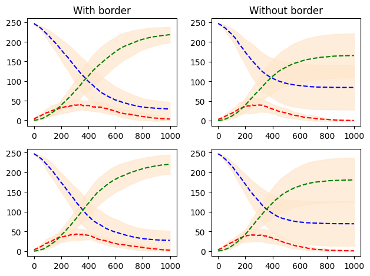

```python
size = 50
pop_size = 250  # size*3
# math.ceil(size*(300*(size/10)))  # size = time_steps/(3*200)
time_steps = 1000
no_init_infected = 3  # math.ceil(pop_size/100)
iterations = 25  # math.ceil(time_steps/pop_size)
seeds = [480, 720]  # np.arange(10*n, 10*(n+1))
recovery_probability = 1e-2
infection_probability = 85e-2
borders = []
noBorders = []
for seed in seeds:
    borders.append(RandomlyViral(
        iterations=iterations,
        no_init_infected=no_init_infected,
        population_size=pop_size,
        nx=size,
        ny=size,
        time_steps=time_steps,
        recovery_probability=recovery_probability,
        infection_probability=infection_probability,
        Recovery="on",
        random_seed=seed))
    noBorders.append(RandomlyViral(
        iterations=iterations,
        no_init_infected=no_init_infected,
        population_size=pop_size,
        nx=size,
        ny=size,
        time_steps=time_steps,
        recovery_probability=recovery_probability,
        infection_probability=infection_probability,
        Recovery="on",
        no_border=True,
        random_seed=seed))

print(f"Current parameters:\nsize={size}\ntime_steps={time_steps}")
print(f"pop_size={pop_size}\nno_init_infected={no_init_infected}")
print(f"iterations={iterations}\nseeds={seeds}")
print(
    f"recovery_probability={recovery_probability}\ninfection_probability={infection_probability}")


numPlots = 2*len(seeds)
fig, axs = plt.subplots(int(numPlots/2), 2)
axs = axs.T.flatten()
for i, (border, noBorder) in enumerate(zip(borders, noBorders)):
    border.plot_simulation(ax=axs[i])
    noBorder.plot_simulation(ax=axs[int(numPlots/2) + i])

axs[0].set_title('With border')
axs[int(numPlots/2)].set_title('Without border')
fig.tight_layout()
```

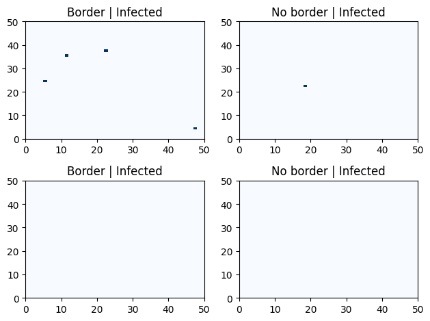

```python
fig, axs = plt.subplots(2, 2)
for i, (border, noBorder) in enumerate(zip(borders, noBorders)):
    border.plot_grid_heatmap(title="Border | Infected",
                             numbers=False, pretty=True, state=1, ax=axs[i,0])
    noBorder.plot_grid_heatmap(
        title="No border | Infected", numbers=False, pretty=True, state=1, ax=axs[i,1])

fig.tight_layout()
```

Following is some simulations done with the default values, and infection waves enabled.

Using 3 waves with probability of infecting;

1. Susceptible people $=10\%$
2. Recovered people $=30\%$

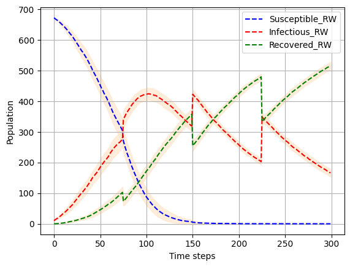

```python
RandomlyViral(Recovery='on', no_border=False,
              wave_susc=0.1,
              wave_reco=0.3,
              num_waves=3,
              infectionWaves=True).plot_simulation()
```

Using 10 waves with probability of infecting;

1. Susceptible people $=1\%$
2. Recovered people $=3\%$

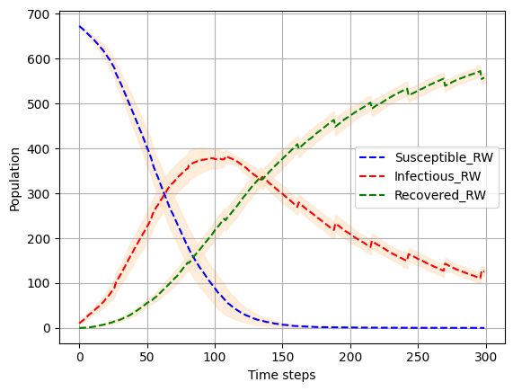

```python
RandomlyViral(Recovery='on', no_border=False,
              wave_susc=0.01,
              wave_reco=0.03,
              num_waves=10,
              infectionWaves=True).plot_simulation()
```

It works as expected, and ripples the data as expected.